# Body performance

### 1. Problem:

With the increasing prevalence of smartphones, technology has had a profound impact on our daily lives, including how we interact with our bodies.By analyzing the body performance dataset, We aim to solve the problem of understanding the factors that contribute to optimal body performance and developing practical solutions.This research is crucial because it can improve athletic performance, prevent injuries, and enhance overall well-being. By analyzing the dataset, we hope to uncover patterns and correlations that will help us optimize training programs.

### Goal :

The primary objective of this project is to emphasize the significance of body performance in enhancing physical health and promoting exercise awareness among individuals. This will be accomplished by analyzing and extracting valuable insights from body performance datasets, monitoring the progression of human age, and subsequently improving the overall awareness of its importance.

### 2. Data Mining task:

#### 2.1 Classification gaol :

Using the attribute “class” as our class label, we employ a classification approach to categorize individuals into different levels of fitness. This classification is based on a range of data attributes, including body measurements such as weight, body fat percentage, health indicators, and activity levels. Our objective extends beyond classification, as we also strive to predict performance outcomes by leveraging the collected data.

#### 2.2 Clustering gaol :

Our primary goal in utilizing clustering on our dataset is to identify inherent patterns or groupings within the data. By applying clustering algorithms, we aim to partition the dataset into distinct clusters based on similarities or shared characteristics among the data points. This enables us to gain insights into the underlying structure of the data, discover relationships between data points, and potentially uncover valuable knowledge or trends that may be hidden within the dataset.

### 3. Data:

#### 3.1: Data Source :

It from Kaggle website , The link(https://www.kaggle.com/datasets/kukuroo3/body-performance-data) show the source data.

### 3.2: General Information about Body performance dataset :

Table 1 : Data dictionary showing description of all Attributes

| name | description | data type | possible value |
| --- | --- | --- | --- |
| Age | The person’s age in years | numerical | 21-64 |
| Gender | The person’s gender | binary | F,M |
| Height_cm | The person’s Height in cm | numerical | 125-194 |
| weight_kg | The person’s weight in Kg | numerical | 26.3-138 |
| body fat_% | the amount of essential fat . | numerical | 3%-78.4% |
| diastolic | measures pressure the blood vessels when the heart is at rest | numerical | 0-156 |
| systolic | measures pressure in the arteries when the heart beats in minutes | numerical | 0-201 |
| gripForce | fingers flexibility tests | numerical | 0-70.5 |
| sit and bend forward_cm | measures flexibility in sitting and bending forward in centimeters. | numerical | -25-213 |
| sit-ups counts_cm | measures the strength and endurance of the abdominals and hip-flexor muscles in centimeter. | numerical | 0-80 |
| broad jump_cm | It is a method of measuring how far a person can jump from a standing position to a landing position. | numerical | 0-303 |
| class | body performance score | numerical | A,B,C,D |

### 3.3: Importing the dataset:

```r
dataset<- read.csv("bodyPerformance.csv")
View(dataset)
str(dataset)
```

```
'data.frame':   13393 obs. of  12 variables:
 $ age                    : num  27 25 31 32 28 36 42 33 54 28 ...
 $ gender                 : chr  "M" "M" "M" "M" ...
 $ height_cm              : num  172 165 180 174 174 ...
 $ weight_kg              : num  75.2 55.8 78 71.1 67.7 ...
 $ body.fat_.             : num  21.3 15.7 20.1 18.4 17.1 22 32.2 36.9 27.6 14.4 ...
 $ diastolic              : num  80 77 92 76 70 64 72 84 85 81 ...
 $ systolic               : num  130 126 152 147 127 119 135 137 165 156 ...
 $ gripForce              : num  54.9 36.4 44.8 41.4 43.5 23.8 22.7 45.9 40.4 57.9 ...
 $ sit.and.bend.forward_cm: num  18.4 16.3 12 15.2 27.1 21 0.8 12.3 18.6 12.1 ...
 $ sit.ups.counts         : num  60 53 49 53 45 27 18 42 34 55 ...
 $ broad.jump_cm          : num  217 229 181 219 217 153 146 234 148 213 ...
 $ class                  : chr  "C" "A" "C" "B" ...
```

### 4. Data Preptocessing:

### 4.1 performance dataset before preprocessing:

```r
print(dataset)
```

| age | gender | height_cm | weight_kg | body.fat_. | diastolic | systolic | gripForce | sit.and.bend.forward_cm | sit.ups.counts | broad.jump_cm | class |
| --- | --- | --- | --- | --- | --- | --- | --- | --- | --- | --- | --- |
| 27 | M | 172.3 | 75.24 | 21.30000 | 80 | 130 | 54.90 | 18.4 | 60 | 217 | C |
| 25 | M | 165.0 | 55.80 | 15.70000 | 77 | 126 | 36.40 | 16.3 | 53 | 229 | A |
| 31 | M | 179.6 | 78.00 | 20.10000 | 92 | 152 | 44.80 | 12.0 | 49 | 181 | C |
| 32 | M | 174.5 | 71.10 | 18.40000 | 76 | 147 | 41.40 | 15.2 | 53 | 219 | B |
| 28 | M | 173.8 | 67.70 | 17.10000 | 70 | 127 | 43.50 | 27.1 | 45 | 217 | B |
| 36 | F | 165.4 | 55.40 | 22.00000 | 64 | 119 | 23.80 | 21.0 | 27 | 153 | B |
| 42 | F | 164.5 | 63.70 | 32.20000 | 72 | 135 | 22.70 | 0.8 | 18 | 146 | D |
| 33 | M | 174.9 | 77.20 | 36.90000 | 84 | 137 | 45.90 | 12.3 | 42 | 234 | B |
| 54 | M | 166.8 | 67.50 | 27.60000 | 85 | 165 | 40.40 | 18.6 | 34 | 148 | C |
| 28 | M | 185.0 | 84.60 | 14.40000 | 81 | 156 | 57.90 | 12.1 | 55 | 213 | B |

[output cut: 990 more lines]

```r
#Number of rows
nrow(dataset)
```

```
[1] 13393
```

```r
#Number of column
ncol(dataset)
```

```
[1] 12
```

### 4.2 Understanding the dataset using graph representations:

### Encoding:

In order to represent the nominal attributes (gender) and (class) in graphs, we had to encode them as they cannot be directly displayed in their original form.

```r
 #encoding Class:
dataset$class = factor(dataset$class,levels =
                        c("A","B", "C","D"), labels = c(1, 2, 3,4))
```

```r
 #encoding Gender:
dataset$gender = factor(dataset$gender,levels =
                         c("F","M"), labels = c(0,1))
```

### 4.5 check if the dataset is balanced or imbalanced (Class boxplot) :

After encoding the attribute (class) We employ a Boxplot graph on our class label (class) to ascertain whether our dataset is balanced or not.

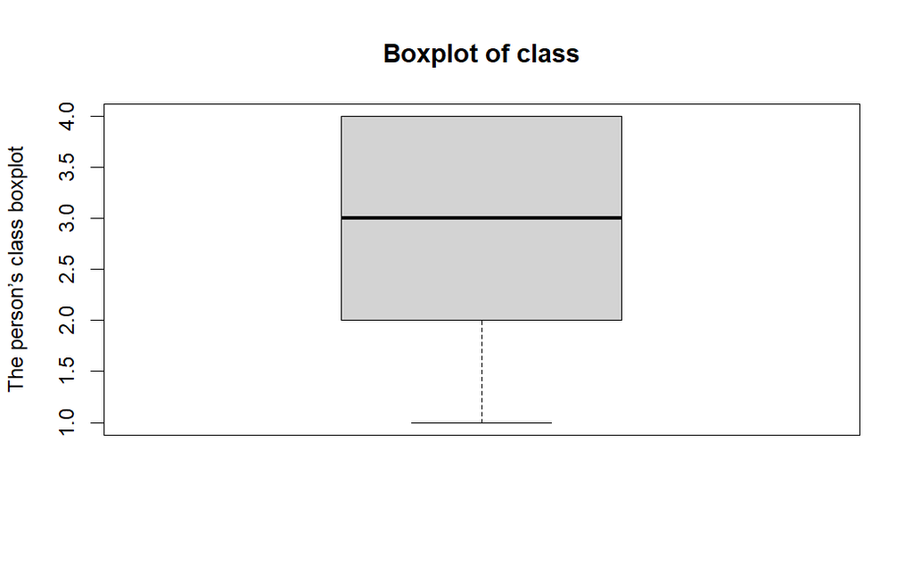

```r
boxplot(dataset$class,
        ylab= "The person’s class boxplot",
        main= "Boxplot of class")
```

Since the median is positioned in the middle of the box plot, it indicates that our dataset is balanced, and there is no need to perform any sampling.

#### 1- Scatter plot for Gender and class :

first we endcode the gender F to be 0 and M to 1, then we use the plot to determine the relationship between gender and class attributes , we notice that the female have higher performance then male.

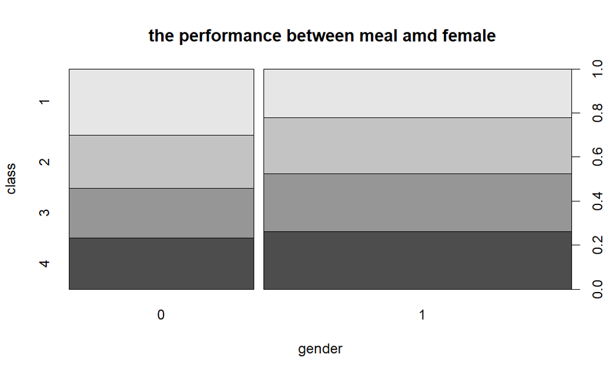

```r
plot(dataset$gender, dataset$class, main = " the performance between meal amd female",
     xlab = "gender", ylab = "class",
     xlim = c(0,1), ylim = c(0,4))
```

#### 2- Scatter plot of height and weight:

Observation:

This scatter plot helps us determine whether height and weight are correlated to each other or not. The plot shows a strong positive correlation between the two attributes, indicating a proportional relationship.

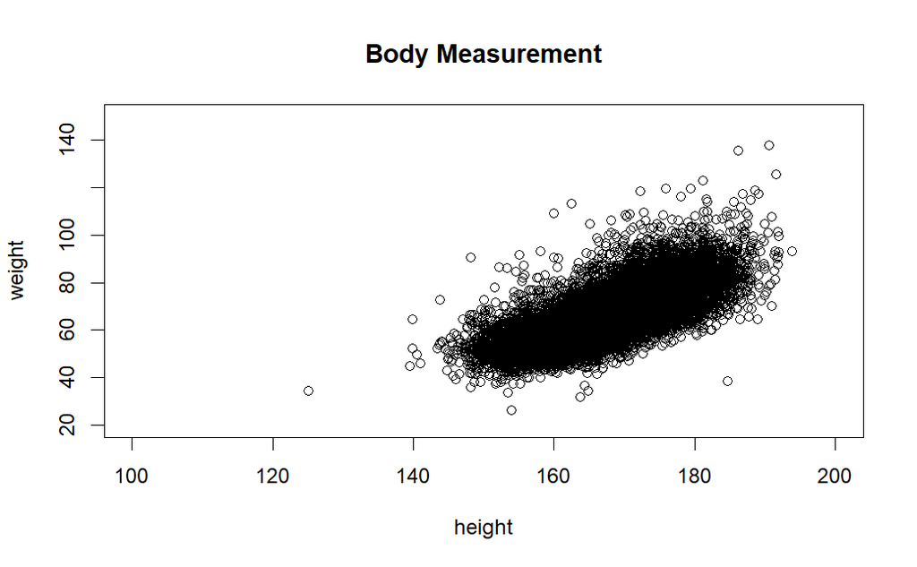

```r
plot(dataset$height_cm, dataset$weight_kg, main = "Body Measurement",
     xlab = "height", ylab = "weight",
     xlim = c(100,200), ylim = c(20,150))
```

#### 3- Histogram of body fat :

Observation:

he histogram represents the frequency distribution of body fat values. We observe that the majority of values lie within the range of 10-30. However, the histogram also reveals the presence of outliers in the dataset .

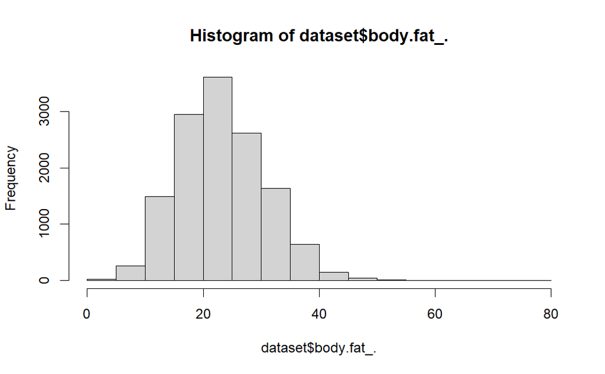

```r
hist(dataset$body.fat_.)
```

#### 4- Scatter plot for age and diastoic :

Observation :

This scatter plot helps us determine the correlation between Age and diastolic. The plot shows no correlation between the two attributes, indicating no proportional relationship

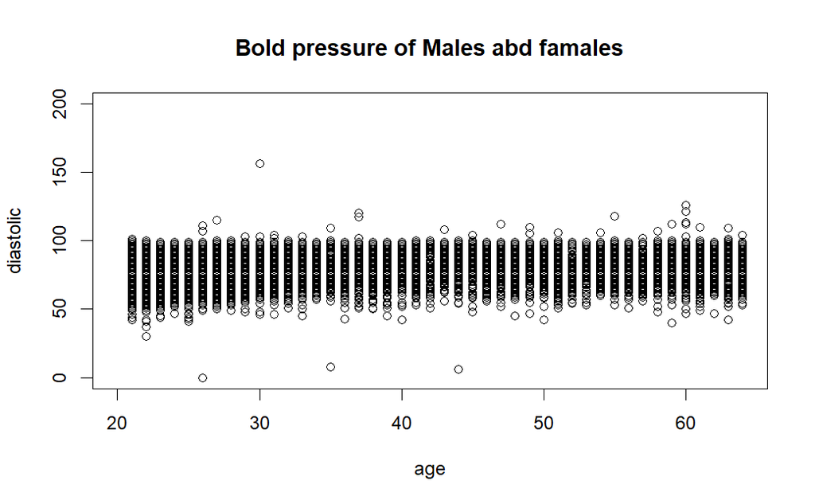

```r
plot(dataset$age, dataset$diastolic, main = "Bold pressure of Males abd famales",
     xlab = "age", ylab = "diastolic",
     xlim = c(20,64), ylim = c(0,200))
```

### 4.3 Statistical Measures:

```r
 summary(dataset$age)
```

```
   Min. 1st Qu.  Median    Mean 3rd Qu.    Max.
  21.00   25.00   32.00   36.78   48.00   64.00
```

```r
summary(dataset$height_cm)
```

```
   Min. 1st Qu.  Median    Mean 3rd Qu.    Max.
  125.0   162.4   169.2   168.6   174.8   193.8
```

```r
 summary(dataset$weight_kg)
```

```
   Min. 1st Qu.  Median    Mean 3rd Qu.    Max.
  26.30   58.20   67.40   67.45   75.30  138.10
```

```r
 summary(dataset$body.fat_.)
```

```
   Min. 1st Qu.  Median    Mean 3rd Qu.    Max.
   3.00   18.00   22.80   23.24   28.00   78.40
```

```r
 summary(dataset$diastolic)
```

```
   Min. 1st Qu.  Median    Mean 3rd Qu.    Max.
    0.0    71.0    79.0    78.8    86.0   156.2
```

```r
 summary(dataset$systolic)
```

```
   Min. 1st Qu.  Median    Mean 3rd Qu.    Max.
    0.0   120.0   130.0   130.2   141.0   201.0
```

```r
 summary(dataset$gripForce)
```

```
   Min. 1st Qu.  Median    Mean 3rd Qu.    Max.
   0.00   27.50   37.90   36.96   45.20   70.50
```

```r
 summary(dataset$sit.and.bend.forward_cm)
```

```
   Min. 1st Qu.  Median    Mean 3rd Qu.    Max.
 -25.00   10.90   16.20   15.21   20.70  213.00
```

```r
summary(dataset$sit.ups.counts)
```

```
   Min. 1st Qu.  Median    Mean 3rd Qu.    Max.
   0.00   30.00   41.00   39.77   50.00   80.00
```

```r
 summary(dataset$broad.jump_cm)
```

```
   Min. 1st Qu.  Median    Mean 3rd Qu.    Max.
    0.0   162.0   193.0   190.1   221.0   303.0
```

### 4.4 Check duplicated rows:

We check if there are any duplicated rows to decrease dataset volume. Hence enhancing data quality which leads to better model performance and speed.

```r
sum(duplicated(dataset))
```

```
[1] 1
```

we found 1 row that’s duplicate that need to be deleted.

```r
#Remove duplicated rows
dataset <- dataset[!duplicated (dataset), ]
```

```r
#To make sure that the deletion was successful
sum(duplicated(dataset))
```

```
[1] 0
```

### 4.5 Check nulls value:

Null values can cause issues when performing data analysis or building machine learning models, as they can lead to inaccurate results or errors, where we found then 0 null in our dataset. So, no need to delete any.

```r
#to find the total null values in the dataset
sum(is.na(dataset))
```

```
[1] 0
```

## 4.6 Detect Outlier and Remove them:

We checked our dataset to see if there were any outlier values, and we found a couple. Statistical studies and modeling can be significantly impacted by the presence of outliers. Outliers can skew results and impair the validity and reliability of inferences made from the research since they are data points that differ dramatically from the majority of the data. Therefore, in order to prevent them from harming our outcomes, we must erase them before we begin our task.

An outlier detection approach was used on the dataset to solve this problem. The detection approach used makes use of the Outliers package’s Outlier() function. This method revealed the outliers among the data points.

```r
#install outliers package:
 library(outliers)
```

#### boxplot to detect outliers:

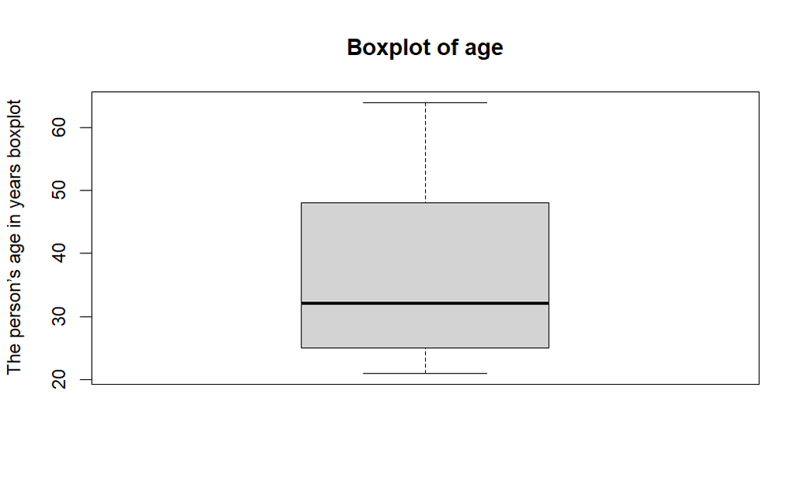

```r
# age boxplot :
boxplot(dataset$age ,
        ylab= "The person’s age in years boxplot",
        main= "Boxplot of age")
```

The summary and box plot values for The person’s height in cm indicate a dataset ranging from 125.0 to 193.8. the median at 169.2, and the mean is 168.6. Comparing the mean and median, we observe that they are relatively close in value. Also, there is some outliers that we will handle it by deleting them in preprocessing steps.

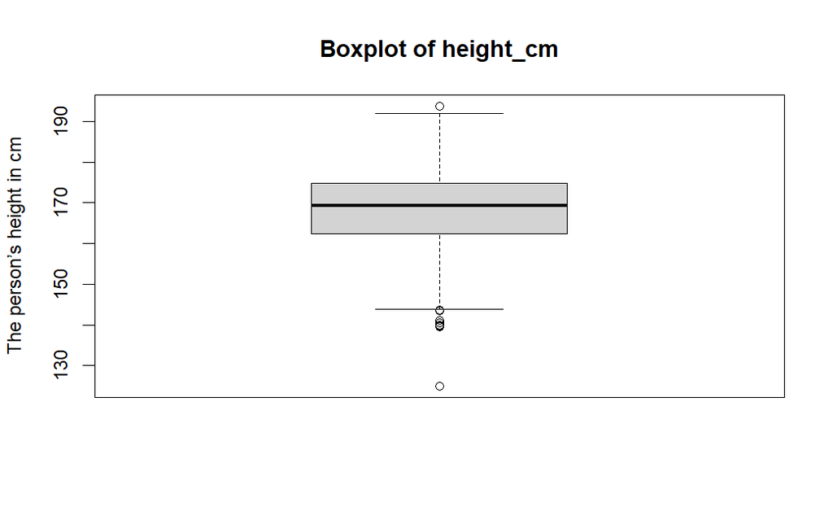

```r
#Hight boxplot :
boxplot(dataset$height_cm ,
        ylab= "The person’s height in cm",
        main= "Boxplot of height_cm")
```

The summary and box plot values for The person’s weight in Kg indicate a dataset ranging from 26.30 to 138.10. The mean weight is 67.45. Comparing the mean and median, we observe that they are relatively close in value, and that due also the maximum outliers.

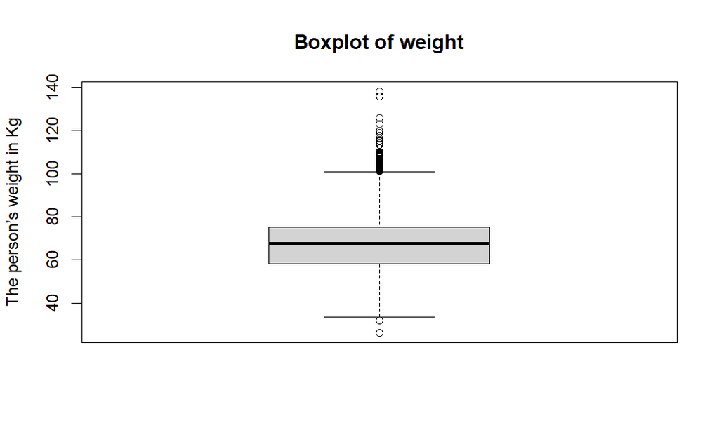

```r
#Weight boxplot;
boxplot(dataset$weight_kg ,
        ylab= "The person’s weight in Kg",
        main= "Boxplot of weight")
```

The boxplot of the person’s body fat (the amount of essential fat .) shows how the values in the dataset have been evenly distributed around the median value of 22.80, and, there some outliers that we will handle them.

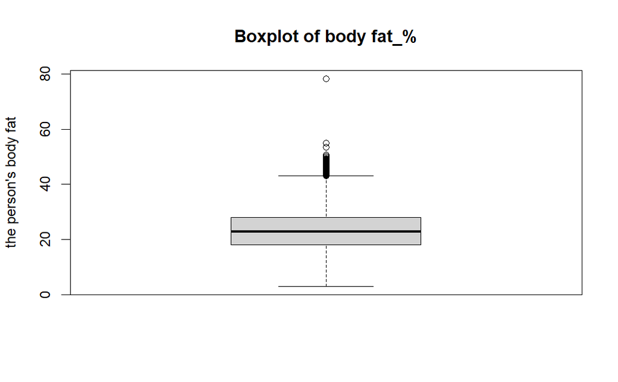

```r
#body fat boxplot :
boxplot(dataset$body.fat_.,
        ylab= "the person's body fat" ,
        main= "Boxplot of body fat_%")
```

The boxplot of the person’s diastolic (measures pressure the blood vessels when the heart is at rest) shows how the values in the dataset have been evenly distributed around the median value of 79.0, and, there some outliers that we will handle them

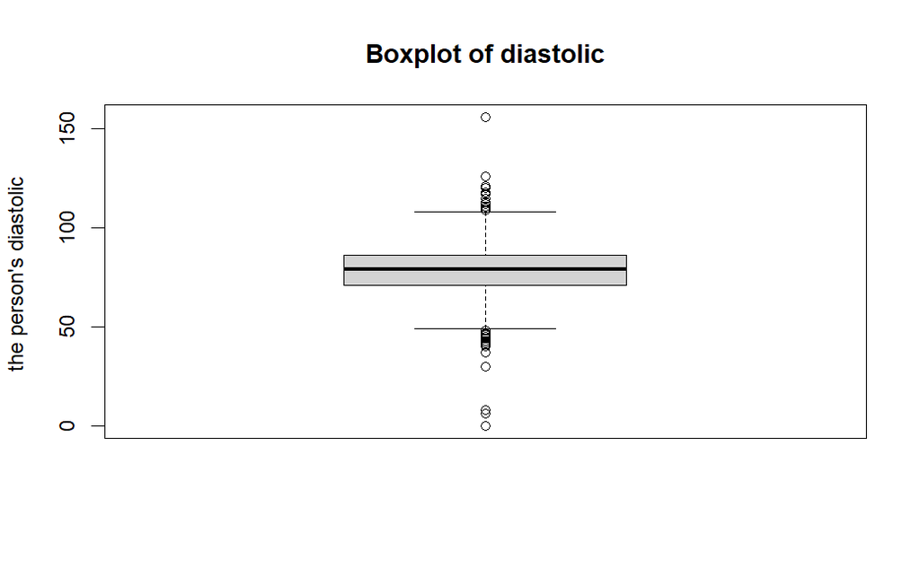

```r
#diastolic box plot :
boxplot(dataset$diastolic,
        ylab= "the person's diastolic ",
        main= "Boxplot of diastolic")
```

The boxplot of the person’s systolic (measures pressure in the arteries when the heart beats in minutes) shows how the values in the dataset have been evenly distributed around the median value of 130.0, and, there some outliers that we will handle them.

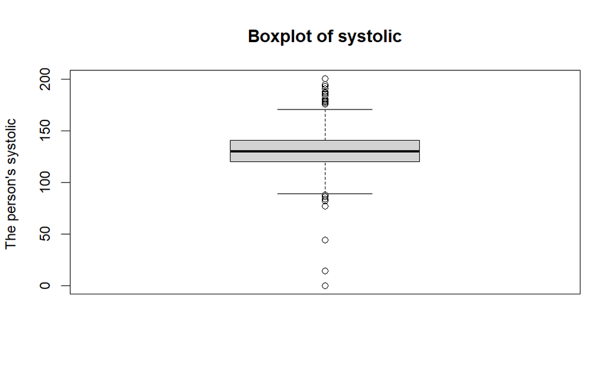

```r
#systolic box plot:
boxplot(dataset$systolic,
        ylab= "The person's systolic " ,
        main= "Boxplot of systolic")
```

The boxplot of gripForce (fingers flexibility tests) shows how the values in the dataset have been evenly distributed around the median value of 37.90, and, there some outliers that we will handle them

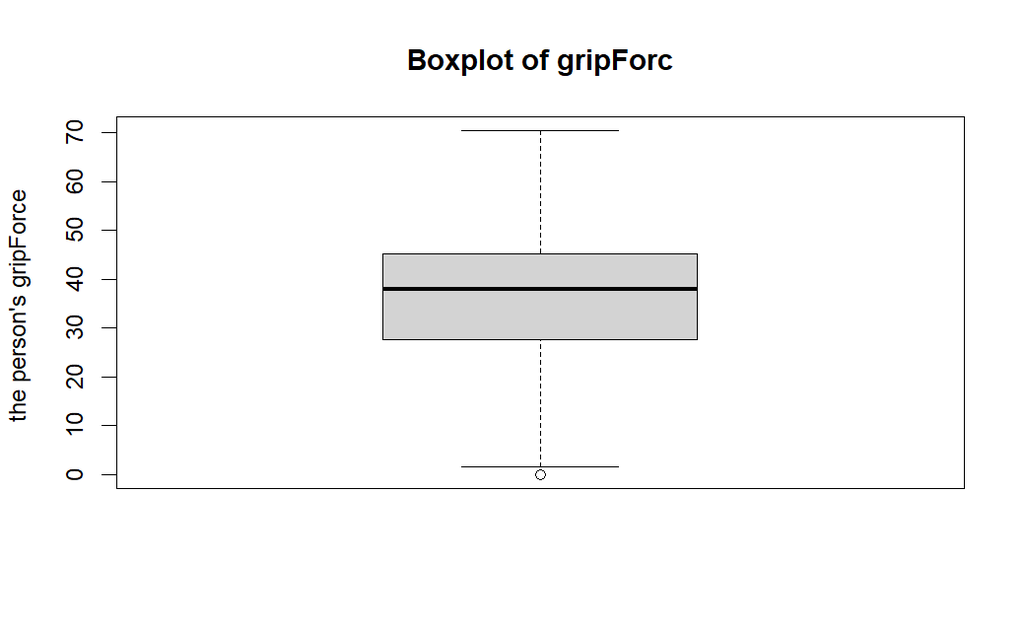

```r
#gripForce box plot:
boxplot(dataset$gripForc,
        ylab= "the person's gripForce " ,
        main= "Boxplot of gripForc")
```

the test that’s measures flexibility in sitting and bending forward in centimeters” boxplot illustrates a slight down skew (negatively skewed) in the distribution, where there are more extreme values on the lower end(outliers) that we will handle it in preprocessing step by deleting them.

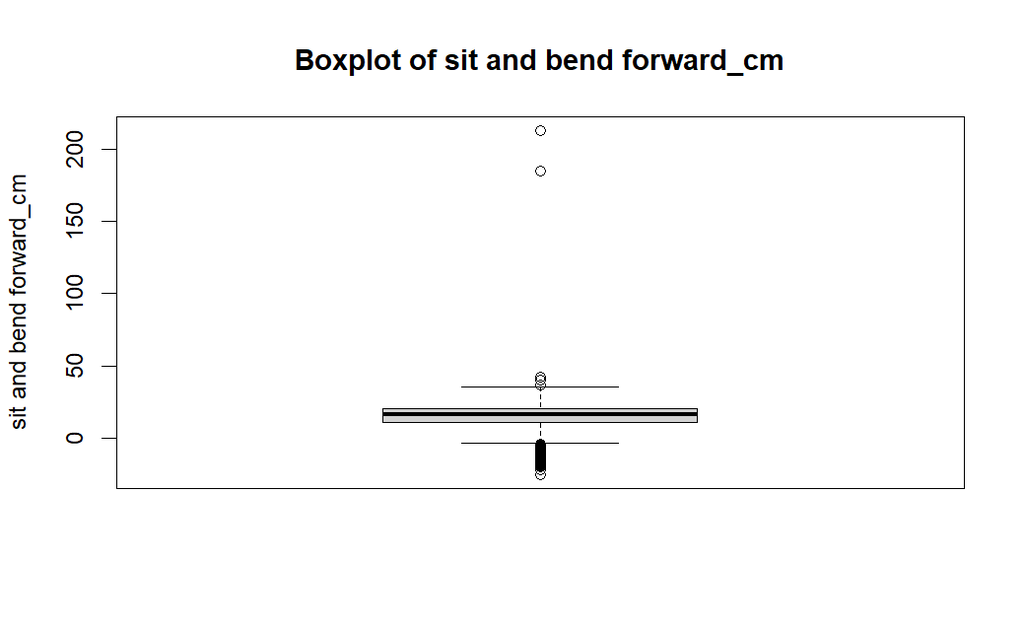

```r
#sit and bend forward_cm box plot:
boxplot(dataset$sit.and.bend.forward_cm,
        ylab= "sit and bend forward_cm" ,
        main= "Boxplot of sit and bend forward_cm")
```

The boxplot of the “Test that measures the strength and endurance of the abdominals and hip-fle” shows how the values in the dataset have been evenly distributed around the median value of 41, and, there’s no outliers showing on boxplot.

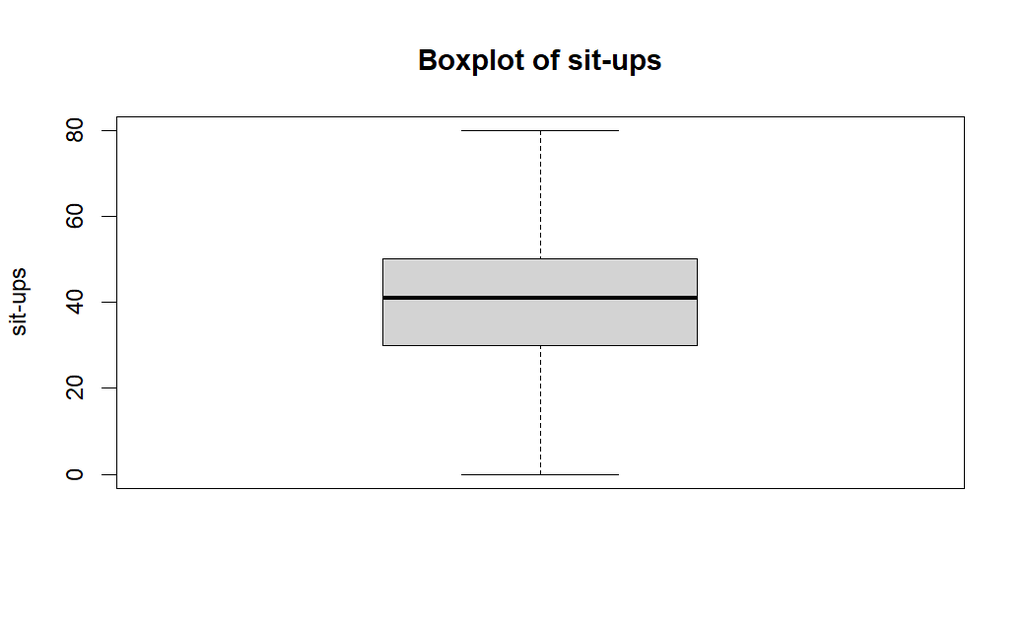

```r
#sit-ups counts_cm box plot:
boxplot(dataset$sit.ups.counts,
        ylab= "sit-ups" ,
        main= "Boxplot of sit-ups")
```

The boxplot of the “method of measuring how far a person can jump from a standing position to a landing position” shows how the values in the dataset have been evenly distributed around the median value of 193, and, there some minimum outliers that we will handle them in preprocessing step by deleting them.

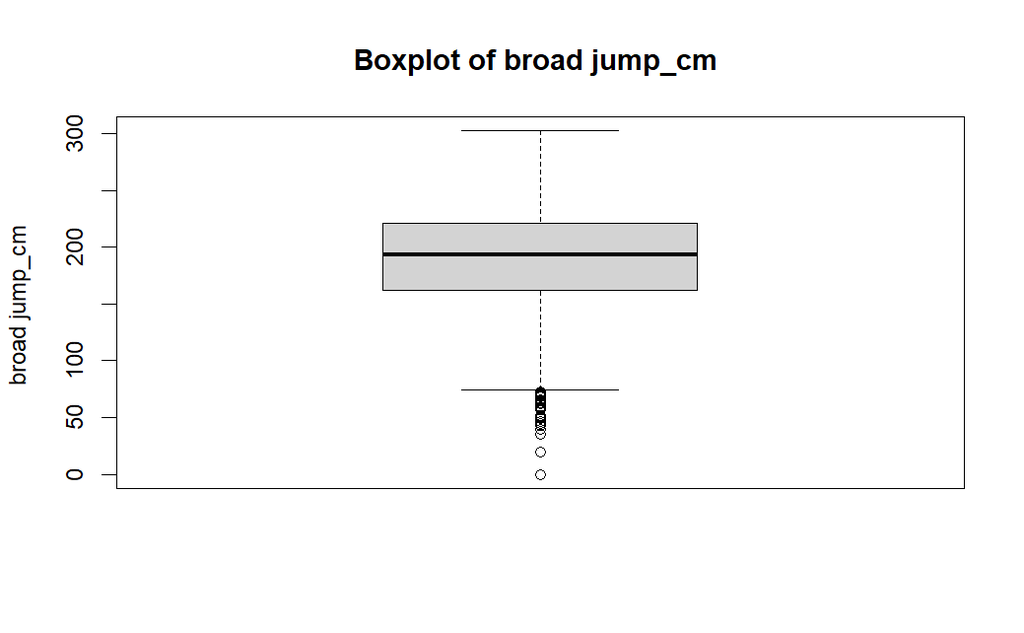

```r
#broad jump_cm box plot:
boxplot(dataset$broad.jump_cm,
        ylab= "broad jump_cm " ,
        main= "Boxplot of broad jump_cm ")
```

### Detect outlirs:

We noticed that “Age” has an Outlier that it’s not showing on the boxplot, where its an Outlier within the range. that’s mean those values are negatively affects on the dataset even though it is within range. So, we delete them

```r
#Detect outlir for 'age':
outAge = outlier(dataset$age, logical =TRUE)

#number of outliers:

sum(outAge)
```

```
[1] 215
```

```r
Find_outlier = which(outAge ==TRUE, arr.ind = TRUE)
outAge
```

[output not shown]

[output cut: 70 more lines]

```r
Find_outlier
```

```
  [1]   182   306   308   343   403   421   433   629   704   761   900   930
 [13]   948  1061  1103  1122  1153  1199  1356  1485  1550  1635  1647  1661
 [25]  1857  1985  2008  2033  2085  2253  2307  2369  2375  2395  2402  2421
 [37]  2533  2558  2587  2619  2647  2664  2769  2783  2881  2918  2988  3032
 [49]  3050  3063  3159  3228  3479  3484  3524  3545  3787  3792  3885  3941
 [61]  3975  4067  4139  4163  4256  4297  4432  4441  4542  4553  4620  4636
 [73]  4821  4828  4882  4934  4946  4950  4999  5030  5085  5124  5125  5210
 [85]  5216  5249  5288  5408  5427  5448  5473  5496  5546  5565  5635  5730
 [97]  5826  5932  6008  6331  6348  6591  6618  6619  6706  6733  6781  6850
[109]  6996  7132  7134  7390  7394  7396  7512  7601  7624  7641  7644  7665
[121]  7682  7739  7864  7930  7943  7994  8007  8183  8187  8228  8268  8308
[133]  8344  8981  9026  9027  9044  9054  9067  9068  9091  9188  9300  9476
[145]  9553  9575  9684  9744  9753  9824  9828  9902  9973 10057 10129 10163
[157] 10181 10441 10535 10544 10741 10851 10883 10888 11055 11062 11099 11129
[169] 11130 11191 11238 11269 11332 11443 11677 11709 11749 11808 11839 11849
[181] 11894 11930 11983 12020 12033 12036 12069 12101 12117 12140 12153 12239
[193] 12254 12273 12278 12323 12486 12490 12499 12530 12544 12593 12599 12762
[205] 12828 13086 13088 13146 13188 13225 13295 13302 13373 13384 13391
```

```r
#Delete age outliers:
dataset= dataset[-Find_outlier,]
```

```r
#Detect outlir for 'height_cm':
outH = outlier(dataset$height_cm, logical =TRUE)
#number of outliers:
sum(outH)
```

```
[1] 1
```

```r
Find_outlier = which(outH ==TRUE, arr.ind = TRUE)
outH
```

[output not shown]

[output cut: 70 more lines]

```r
Find_outlier
```

```
[1] 8122
```

```r
#Delete height_cm outliers:
dataset= dataset[-Find_outlier,]
```

```r
#Detect outlir for 'weight_kg':
outW= outlier(dataset$weight_kg, logical =TRUE)
#number of outliers:
sum(outW)
```

```
[1] 1
```

```r
Find_outlier = which(outW ==TRUE, arr.ind = TRUE)
outW
```

[output not shown]

[output cut: 70 more lines]

```r
Find_outlier
```

```
[1] 10976
```

```r
#Delete weight_kg outliers:
dataset= dataset[-Find_outlier,]
```

```r
#Detect outlir for 'body.fat\_.':

outefat = outlier(dataset$body.fat_., logical =TRUE)
#number of outliers:
sum(outefat)
```

```
[1] 1
```

```r
Find_outlier = which(outefat ==TRUE, arr.ind = TRUE)
outefat
```

[output not shown]

[output cut: 70 more lines]

```r
Find_outlier
```

```
[1] 727
```

```r
#Delete body.fat outliers:
dataset= dataset[-Find_outlier,]
```

```r
#Detect outlir for 'systolic':
outesys = outlier(dataset$systolic, logical =TRUE)
#number of outliers:
sum(outesys)
```

```
[1] 1
```

```r
Find_outlier = which(outesys ==TRUE, arr.ind = TRUE)
outesys
```

[output not shown]

[output cut: 70 more lines]

```r
Find_outlier
```

```
[1] 10463
```

```r
#Delete systolic outliers:
dataset= dataset[-Find_outlier,]
```

As we saw in boxplot there was only one outlier. However, here we detected 3 values, where 2 are within the range but we will take it as an outliers sinces those values may have a negatively affects on the dataset specifically on “class” attribute.

```r
#Detect outlir for 'gripForce':
outegrip = outlier(dataset$gripForce, logical =TRUE)
#number of outliers:
sum(outegrip)
```

```
[1] 3
```

```r
Find_outlier = which(outegrip ==TRUE, arr.ind = TRUE)
outegrip
```

[output not shown]

[output cut: 70 more lines]

```r
Find_outlier
```

```
[1] 8428 9341 9618
```

```r
#Delete gripForce  outliers:
dataset= dataset[-Find_outlier,]
```

```r
#Detect outlir for 'sit.and.bend.forward_cm':
outesit = outlier(dataset$sit.and.bend.forward_cm, logical =TRUE)
#number of outliers:
sum(outesit)
```

```
[1] 1
```

```r
Find_outlier = which(outesit ==TRUE, arr.ind = TRUE)
outesit
```

[output not shown]

[output cut: 70 more lines]

```r
Find_outlier
```

```
[1] 2616
```

```r
#Delete sit.and.bend.forward_cm outliers:
dataset= dataset[-Find_outlier,]
```

we notic some outliers within the range and we will deleting them as an outliers since it’s effects other attributes negatively.

```r
#Detect outlir for 'sit.up.count':
outesitup = outlier(dataset$sit.ups.counts, logical =TRUE)
#number of outliers:
sum(outesitup)
```

```
[1] 113
```

```r
Find_outlier = which(outesitup ==TRUE, arr.ind = TRUE)
outesitup
```

[output not shown]

[output cut: 70 more lines]

```r
Find_outlier
```

```
  [1]    12   137   189   401   493   531   673   704  1003  1674  1715  1835
 [13]  1894  2031  2136  2294  2391  2394  2500  2536  2557  2567  2743  2750
 [25]  2832  2935  3036  3115  3194  3374  3422  3827  3832  4303  4304  4318
 [37]  4380  4382  4411  4494  4809  4824  4866  5071  5312  5345  5475  5486
 [49]  5520  5539  5840  5942  5957  6275  6278  6372  6384  6481  6490  7238
 [61]  7267  7297  7302  7315  7449  7771  7828  7877  7938  7978  7996  8097
 [73]  8359  8416  8463  8617  8630  8753  8902  9003  9034  9513  9644  9720
 [85]  9828  9973 10073 10213 10233 10268 10443 10483 10534 10601 10798 10828
 [97] 10875 10896 11110 11265 11365 11421 11515 11518 11898 11967 11995 12035
[109] 12046 12148 12420 12467 12514
```

```r
#Delete age outliers:
dataset= dataset[-Find_outlier,]
```

```r
#Detect outlir for 'broad.jump_cm':

Outjump = outlier(dataset$broad.jump_cm, logical =TRUE)
sum(Outjump)
```

```
[1] 5
```

```r
Find_outlier = which(Outjump ==TRUE, arr.ind = TRUE)
Outjump
```

[output not shown]

[output cut: 70 more lines]

```r
Find_outlier
```

```
[1]  474 4643 7194 7534 7752
```

```r
dataset= dataset[-Find_outlier,]
```

### Check rows and columns after deletion the outliers:

To make sure that the deletion was successful, we searched for the number of rows.

```r
#check after deleting
#Number of rows and column
nrow(dataset)
```

```
[1] 13051
```

```r
ncol(dataset)
```

```
[1] 12
```

We noticed a decrease in the number of rows, which means that deletion the outliers was successful.

### Discretization :

```r
#To use it later in clustering task:
AgeBeforeDis <- dataset$age
```

```r
# Define bins for discretization
dataset$age=cut(dataset$age, breaks = seq(21,64, by=14), right=FALSE)
```

### Normalizetion:

In order to ensure comparability across individuals and eliminate biases resulting from differences in measurement units or scales, we have decided to normalize the following attributes: height (in centimeters), weight (in kilograms), body fat percentage, diastolic, systolic, grip force, sit and bend forward distance (in centimeters), sit-ups count, and broad jump distance (in centimeters).

```r
View(dataset)
dataset [,3:4:5:6:7:8:9:11]=scale(dataset [,3:4:5:6:7:8:9:11])
```

### Feature Selection :

Based on the dataset and the graphs we did earlier, there are several justifications for not performing feature selection:

#### 1. Dimensionality:

The number of attributes (12) is not excessively high, and it is within a manageable range for modeling and analysis.

#### 2.Correlation Assessment:

just because some graphs indicate a lack of correlation between certain attributes, it doesn’t imply that those attributes hold no value or provide no assistance in enhancing individual body performance. It is important to recognize the interplay between these attributes and their impact on body performance. Consequently, removing any of these attributes may result in loss of valuable information.

#### 3. Interpretability:

By considering all the attributes, you can gain a deeper understanding of the relationships between different variables, and allows for a more comprehensive analysis providing more meaningful insights.

While feature selection can be beneficial in certain situations, in the case of analyzing body performance for individuals, it is important to consider all attributes without performing feature selection.

### 5 Data Mining Task:

### 5.1 Classification:

Our classification objective is to develop a predictive model for our dataset with class labels A, B, C, and D based on various attributes. To address the challenge of a small dataset, we will employ a partitioning strategy suitable for limited data, utilizing three different sizes for training and testing sets. We will adopt the sampling method, allowing replacement of attributes with ‘True’ values. For each partition size, we will build three decision trees, employing distinct attribute selection methods: Information Gain (ID3), Gain Ratio (C4.5), and Gini Index (CART). The prediction will be carried out using the ‘predict’ method. Evaluation and testing will be performed using the ‘confusionMatrix’ method.

#### Classification packages:

We install and call predifined packages in R language to help us in classification process. which shown below:

```r
library(party)
library(partykit)
library(RWeka)
library(caret)
library(rpart)
library(rpart.plot)
```

### Partitioning 70/30

```r
set.seed(1234)
ind=sample(2, nrow(dataset), replace=TRUE, prob=c(0.70 , 0.30))
train_data=dataset[ind==1,]
test_data=dataset[ind==2,]
dim(train_data)
```

```
[1] 9176   12
```

```r
dim(test_data)
```

```
[1] 3875   12
```

```r
# Check class distribution in training set
table(train_data$class)
```

```
   1    2    3    4
2300 2310 2328 2238
```

```r
prop.table(table(train_data$class))
```

```
        1         2         3         4
0.2506539 0.2517437 0.2537053 0.2438971
```

```r
# Check class distribution in testing set
table(test_data$class)
```

```
   1    2    3    4
1002  983  964  926
```

```r
prop.table(table(test_data$class))
```

```
        1         2         3         4
0.2585806 0.2536774 0.2487742 0.2389677
```

It appears that both training set and testing set are class balanced, with the counts for each class being approximately equal. This suggests that the distribution of instances across different classes in both the training and testing sets is relatively equal. Each class is represented proportionally, and there is no significant imbalance where a single class dominates the dataset. This balance in class representation is essential for training machine learning models, contributing to fair and unbiased predictions across all classes.

##### Information Gain (ID3):

```r
features <-dataset[, c("gender","age" ,"height_cm",  "weight_kg" , "body.fat_.", "diastolic", "systolic","gripForce", "sit.and.bend.forward_cm","sit.ups.counts","broad.jump_cm")]
target <- as.factor(dataset$class)
dataset$class = as.factor(dataset$class)


# Example of hyperparameter tuning
model <- train(
  x = train_data[, c("gender","age" ,"height_cm",  "weight_kg" , "body.fat_.", "diastolic", "systolic","gripForce", "sit.and.bend.forward_cm","sit.ups.counts","broad.jump_cm")],
  y = train_data$class,
  method = "rpart",parms = list(split = "information"),tuneGrid = data.frame(cp = seq(0.01, 0.1, by = 0.01)),trControl = trainControl(method = "cv", number = 3)
)
```

###### Tree based on information gain:

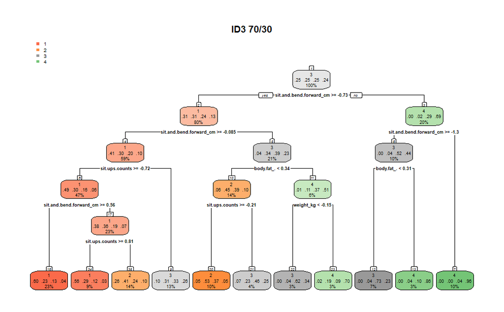

```r
# Load the necessary libraries
library(rpart)
library(rpart.plot)

# Assuming 'model' is your trained model
rpart_model <- model$finalModel

# Print the decision tree
rpart.plot(rpart_model,main="ID3 70/30", box.palette = "auto", nn = TRUE)
```

The decision tree representation was utilized, and the findings indicate that the attribute (sit.and.bend.forward_cm) has the greatest information gain. As a result, it was placed at the root level, representing the first level of the tree.

###### Prediction on test data and Confusion matrix:

```r
testPred<- predict(model,newdata=test_data)
testPred<- factor(testPred)
test_data$class <- factor(test_data$class)
results<- confusionMatrix(testPred,test_data$class)
conf_matrix <- results$table

print(results)
```

```
Confusion Matrix and Statistics

          Reference
Prediction   1   2   3   4
         1 785 313 144  55
         2 154 441 314  96
         3  60 184 476 245
         4   3  45  30 530

Overall Statistics

               Accuracy : 0.576
                 95% CI : (0.5603, 0.5916)
    No Information Rate : 0.2586
    P-Value [Acc > NIR] : < 2.2e-16

                  Kappa : 0.4333

 Mcnemar's Test P-Value : < 2.2e-16

Statistics by Class:

                     Class: 1 Class: 2 Class: 3 Class: 4
Sensitivity            0.7834   0.4486   0.4938   0.5724
Specificity            0.8218   0.8050   0.8320   0.9736
Pos Pred Value         0.6052   0.4388   0.4933   0.8717
Neg Pred Value         0.9158   0.8111   0.8323   0.8788
Prevalence             0.2586   0.2537   0.2488   0.2390
Detection Rate         0.2026   0.1138   0.1228   0.1368
Detection Prevalence   0.3347   0.2594   0.2490   0.1569
Balanced Accuracy      0.8026   0.6268   0.6629   0.7730
```

```r
error_rate <- 1 - sum(diag(conf_matrix)) / sum(conf_matrix)
precision <- diag(conf_matrix) / rowSums(conf_matrix)
specificity <- conf_matrix[1, 1] / sum(conf_matrix[1, ])
sensitivity <- conf_matrix[2, 2] / sum(conf_matrix[2, ])

print(paste("specificity:", specificity))
```

```
[1] "specificity: 0.605242868157286"
```

```r
print(paste("sensitivity", sensitivity))
```

```
[1] "sensitivity 0.438805970149254"
```

```r
print(paste("Error Rate:", error_rate))
```

```
[1] "Error Rate: 0.424"
```

```r
print(paste("Precision for Class 1:", precision[1]))
```

```
[1] "Precision for Class 1: 0.605242868157286"
```

The above matrix is based on applying our model on test data.

#### Schedule for classification Evaluation:

[output not shown]

##### Gain ratio:

```r
# Example of hyperparameter tuning
model <- train(
  x = train_data[, c("gender","age" ,"height_cm",  "weight_kg" , "body.fat_.", "diastolic", "systolic","gripForce", "sit.and.bend.forward_cm","sit.ups.counts","broad.jump_cm")],
  y = train_data$class,
  method = "rpart",parms = list(split = "gain_ratio"),tuneGrid = data.frame(cp = seq(0.01, 0.1, by = 0.01)),trControl = trainControl(method = "cv", number = 3)
)
```

###### Tree based on Gain ratio:

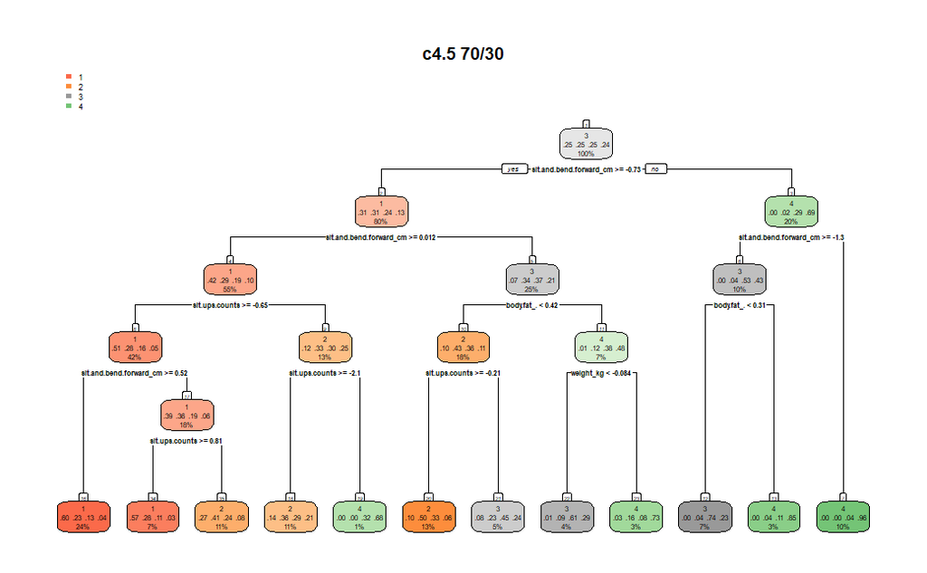

```r
# Load the necessary libraries
library(rpart.plot)

# Assuming 'model' is your trained model
rpart_model <- model$finalModel

# Print the decision tree
rpart.plot(rpart_model,main="c4.5 70/30", box.palette = "auto", nn = TRUE)
```

###### Prediction on test data and Confusion matrix:

```r
testPred<- predict(model,newdata=test_data)
testPred<- factor(testPred)
test_data$class <- factor(test_data$class)
results<- confusionMatrix(testPred,test_data$class)
conf_matrix <- results$table

print(results)
```

```
Confusion Matrix and Statistics

          Reference
Prediction   1   2   3   4
         1 775 310 139  55
         2 210 565 433 156
         3  10  66 349 162
         4   7  42  43 553

Overall Statistics

               Accuracy : 0.5786
                 95% CI : (0.5629, 0.5942)
    No Information Rate : 0.2586
    P-Value [Acc > NIR] : < 2.2e-16

                  Kappa : 0.4365

 Mcnemar's Test P-Value : < 2.2e-16

Statistics by Class:

                     Class: 1 Class: 2 Class: 3 Class: 4
Sensitivity            0.7735   0.5748  0.36203   0.5972
Specificity            0.8246   0.7237  0.91824   0.9688
Pos Pred Value         0.6059   0.4142  0.59455   0.8574
Neg Pred Value         0.9126   0.8335  0.81296   0.8845
Prevalence             0.2586   0.2537  0.24877   0.2390
Detection Rate         0.2000   0.1458  0.09006   0.1427
Detection Prevalence   0.3301   0.3520  0.15148   0.1665
Balanced Accuracy      0.7990   0.6492  0.64014   0.7830
```

```r
error_rate <- 1 - sum(diag(conf_matrix)) / sum(conf_matrix)
precision <- diag(conf_matrix) / rowSums(conf_matrix)
specificity <- conf_matrix[1, 1] / sum(conf_matrix[1, ])
sensitivity <- conf_matrix[2, 2] / sum(conf_matrix[2, ])

print(paste("specificity:", specificity))
```

```
[1] "specificity: 0.605942142298671"
```

```r
print(paste("sensitivity", sensitivity))
```

```
[1] "sensitivity 0.414222873900293"
```

```r
print(paste("Error Rate:", error_rate))
```

```
[1] "Error Rate: 0.42141935483871"
```

```r
print(paste("Precision for Class 1:", precision[1]))
```

```
[1] "Precision for Class 1: 0.605942142298671"
```

The above matrix is based on applying our model on test data.

#### Schedule for classification Evaluation:

[output not shown]

##### Gini index:

```r
# Example of hyperparameter tuning
model <- train(x = train_data[, c("gender","age" ,"height_cm",  "weight_kg" , "body.fat_.", "diastolic", "systolic","gripForce", "sit.and.bend.forward_cm","sit.ups.counts","broad.jump_cm")],
  y = train_data$class,method = "rpart",parms = list(split = "gini"),tuneGrid = data.frame(cp = seq(0.01, 0.1, by = 0.01)),trControl = trainControl(method = "cv", number = 3))
```

###### Tree based on Gini index :

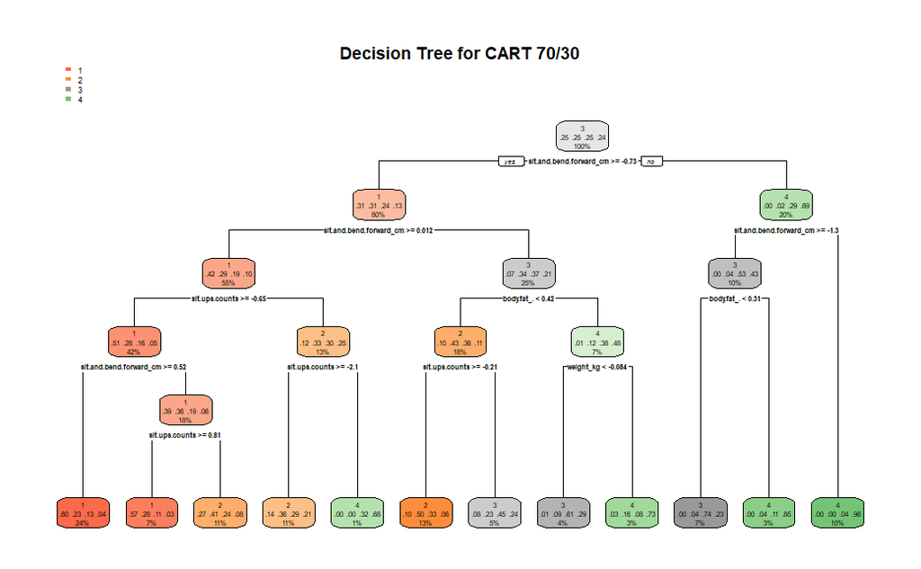

```r
# Load the necessary libraries
library(rpart.plot)

# Assuming 'model' is your trained model
rpart_model <- model$finalModel

# Print the decision tree
rpart.plot(rpart_model, main = "Decision Tree for CART 70/30")
```

The decision tree representation was utilized, and the findings indicate that the attribute (sit.and.bend.forward_cm) has the greatest Giniindex (impurity reduction) values. As a result, it was placed at the root level, representing the first level of the tree.

###### Prediction on test data and Confusion matrix:

```r
testPred<- predict(model,newdata=test_data)
testPred<- factor(testPred)
test_data$class <- factor(test_data$class)
results<- confusionMatrix(testPred,test_data$class)
conf_matrix <- results$table

print(results)
```

```
Confusion Matrix and Statistics

          Reference
Prediction   1   2   3   4
         1 775 310 139  55
         2 210 565 433 156
         3  10  66 349 162
         4   7  42  43 553

Overall Statistics

               Accuracy : 0.5786
                 95% CI : (0.5629, 0.5942)
    No Information Rate : 0.2586
    P-Value [Acc > NIR] : < 2.2e-16

                  Kappa : 0.4365

 Mcnemar's Test P-Value : < 2.2e-16

Statistics by Class:

                     Class: 1 Class: 2 Class: 3 Class: 4
Sensitivity            0.7735   0.5748  0.36203   0.5972
Specificity            0.8246   0.7237  0.91824   0.9688
Pos Pred Value         0.6059   0.4142  0.59455   0.8574
Neg Pred Value         0.9126   0.8335  0.81296   0.8845
Prevalence             0.2586   0.2537  0.24877   0.2390
Detection Rate         0.2000   0.1458  0.09006   0.1427
Detection Prevalence   0.3301   0.3520  0.15148   0.1665
Balanced Accuracy      0.7990   0.6492  0.64014   0.7830
```

```r
error_rate <- 1 - sum(diag(conf_matrix)) / sum(conf_matrix)
precision <- diag(conf_matrix) / rowSums(conf_matrix)
specificity <- conf_matrix[1, 1] / sum(conf_matrix[1, ])
sensitivity <- conf_matrix[2, 2] / sum(conf_matrix[2, ])

print(paste("specificity:", specificity))
```

```
[1] "specificity: 0.605942142298671"
```

```r
print(paste("sensitivity", sensitivity))
```

```
[1] "sensitivity 0.414222873900293"
```

```r
print(paste("Error Rate:", error_rate))
```

```
[1] "Error Rate: 0.42141935483871"
```

```r
print(paste("Precision for Class 1:", precision[1]))
```

```
[1] "Precision for Class 1: 0.605942142298671"
```

The above matrix is based on applying our model on test data.

#### Schedule for classification Evaluation:

[output not shown]

### Partitioning 75/25

```r
set.seed(1234)
ind=sample (2, nrow(dataset), replace=TRUE, prob=c(0.75 , 0.25))
train_data=dataset[ind==1,]
test_data=dataset[ind==2,]
dim(train_data)
```

```
[1] 9819   12
```

```r
dim(test_data)
```

```
[1] 3232   12
```

```r
# Check class distribution in training set
table(train_data$class)
```

```
   1    2    3    4
2446 2479 2480 2414
```

```r
prop.table(table(train_data$class))
```

```
        1         2         3         4
0.2491089 0.2524697 0.2525715 0.2458499
```

```r
# Check class distribution in testing set
table(test_data$class)
```

```
  1   2   3   4
856 814 812 750
```

```r
prop.table(table(test_data$class))
```

```
        1         2         3         4
0.2648515 0.2518564 0.2512376 0.2320545
```

the class is balanced in the training set and testing set.

##### Information Gain (ID3):

```r
features <-dataset[, c("gender","age" ,"height_cm",  "weight_kg" , "body.fat_.", "diastolic", "systolic","gripForce", "sit.and.bend.forward_cm","sit.ups.counts","broad.jump_cm")]
target <- as.factor(dataset$class)
dataset$class = as.factor(dataset$class)

# Example of hyperparameter tuning
model <- train(x = train_data[, c("gender","age" ,"height_cm",  "weight_kg" , "body.fat_.", "diastolic", "systolic","gripForce", "sit.and.bend.forward_cm","sit.ups.counts","broad.jump_cm")],
  y = train_data$class,method = "rpart",parms = list(split = "information"),tuneGrid = data.frame(cp = seq(0.01, 0.1, by = 0.01)),trControl = trainControl(method = "cv", number = 3))
```

###### Tree based on information gain:

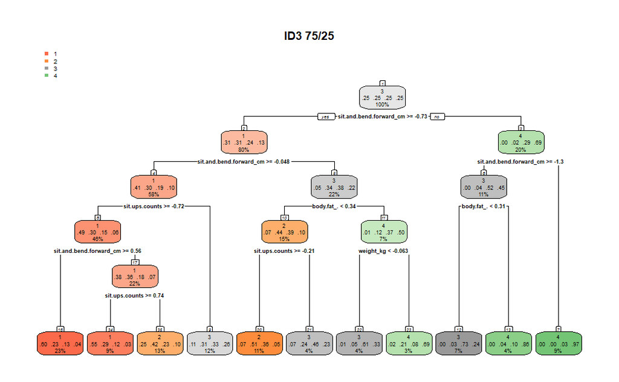

```r
# Load the necessary libraries
library(rpart)
library(rpart.plot)

# Assuming 'model' is your trained model
rpart_model <- model$finalModel

# Print the decision tree
rpart.plot(rpart_model,main="ID3 75/25", box.palette = "auto", nn = TRUE)
```

The decision tree representation was utilized, and the findings indicate that the attribute (sit.and.bend.forward_cm) has the greatest information gain. As a result, it was placed at the root level, representing the first level of the tree.

###### Prediction on test data and Confusion matrix:

```r
testPred<- predict(model,newdata=test_data)
testPred<- factor(testPred)
test_data$class <- factor(test_data$class)
results<- confusionMatrix(testPred,test_data$class)
conf_matrix <- results$table

print(results)
```

```
Confusion Matrix and Statistics

          Reference
Prediction   1   2   3   4
         1 689 273 124  44
         2 111 347 262  71
         3  53 156 399 202
         4   3  38  27 433

Overall Statistics

               Accuracy : 0.578
                 95% CI : (0.5607, 0.5951)
    No Information Rate : 0.2649
    P-Value [Acc > NIR] : < 2.2e-16

                  Kappa : 0.4349

 Mcnemar's Test P-Value : < 2.2e-16

Statistics by Class:

                     Class: 1 Class: 2 Class: 3 Class: 4
Sensitivity            0.8049   0.4263   0.4914   0.5773
Specificity            0.8144   0.8164   0.8302   0.9726
Pos Pred Value         0.6097   0.4387   0.4926   0.8643
Neg Pred Value         0.9206   0.8087   0.8295   0.8839
Prevalence             0.2649   0.2519   0.2512   0.2321
Detection Rate         0.2132   0.1074   0.1235   0.1340
Detection Prevalence   0.3496   0.2447   0.2506   0.1550
Balanced Accuracy      0.8097   0.6213   0.6608   0.7750
```

```r
error_rate <- 1 - sum(diag(conf_matrix)) / sum(conf_matrix)
precision <- diag(conf_matrix) / rowSums(conf_matrix)
specificity <- conf_matrix[1, 1] / sum(conf_matrix[1, ])
sensitivity <- conf_matrix[2, 2] / sum(conf_matrix[2, ])

print(paste("specificity:", specificity))
```

```
[1] "specificity: 0.609734513274336"
```

```r
print(paste("sensitivity", sensitivity))
```

```
[1] "sensitivity 0.438685208596713"
```

```r
print(paste("Error Rate:", error_rate))
```

```
[1] "Error Rate: 0.422029702970297"
```

```r
print(paste("Precision for Class 1:", precision[1]))
```

```
[1] "Precision for Class 1: 0.609734513274336"
```

The above matrix is based on applying our model on test data.

#### Schedule for classification Evaluation:

| Evaluation method | value |
| --- | --- |
| Accuracy | 57.8% |
| Error Rate | 42.20% |
| Sensitivity(Recall) | 43.86% |
| Specificity | 60.97% |
| Precision | 60.97% |

##### Gain ratio:

```r
model <- train(x = train_data[, c("gender","age" ,"height_cm",  "weight_kg" , "body.fat_.", "diastolic", "systolic","gripForce", "sit.and.bend.forward_cm","sit.ups.counts","broad.jump_cm")],
  y = train_data$class,method = "rpart",parms = list(split = "gain_ratio"),tuneGrid = data.frame(cp = seq(0.01, 0.1, by = 0.01)),trControl = trainControl(method = "cv", number = 3))
```

###### Tree based on Gain ratio:

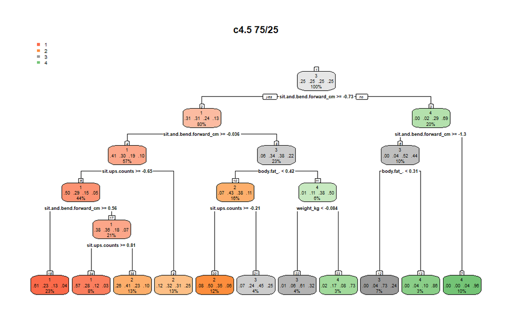

```r
# Load the necessary libraries
library(rpart.plot)

# Assuming 'model' is your trained model
rpart_model <- model$finalModel

# Print the decision tree
rpart.plot(rpart_model,main="c4.5 75/25", box.palette = "auto", nn = TRUE)
```

The decision tree representation was utilized, and the findings indicate that the attribute (sit.and.bend.forward_cm) has the greatest gain ratio. As a result, it was placed at the root level, representing the first level of the tree.

###### Prediction on test data and Confusion matrix:

```r
testPred<- predict(model,newdata=test_data)
testPred<- factor(testPred)
test_data$class <- factor(test_data$class)
results<- confusionMatrix(testPred,test_data$class)
conf_matrix <- results$table

print(results)
```

```
Confusion Matrix and Statistics

          Reference
Prediction   1   2   3   4
         1 667 255 116  41
         2 178 478 380 153
         3   8  48 286 126
         4   3  33  30 430

Overall Statistics

               Accuracy : 0.5758
                 95% CI : (0.5585, 0.5929)
    No Information Rate : 0.2649
    P-Value [Acc > NIR] : < 2.2e-16

                  Kappa : 0.4321

 Mcnemar's Test P-Value : < 2.2e-16

Statistics by Class:

                     Class: 1 Class: 2 Class: 3 Class: 4
Sensitivity            0.7792   0.5872  0.35222   0.5733
Specificity            0.8266   0.7060  0.92479   0.9734
Pos Pred Value         0.6182   0.4020  0.61111   0.8669
Neg Pred Value         0.9122   0.8355  0.80970   0.8830
Prevalence             0.2649   0.2519  0.25124   0.2321
Detection Rate         0.2064   0.1479  0.08849   0.1330
Detection Prevalence   0.3338   0.3679  0.14480   0.1535
Balanced Accuracy      0.8029   0.6466  0.63851   0.7734
```

```r
error_rate <- 1 - sum(diag(conf_matrix)) / sum(conf_matrix)
precision <- diag(conf_matrix) / rowSums(conf_matrix)
specificity <- conf_matrix[1, 1] / sum(conf_matrix[1, ])
sensitivity <- conf_matrix[2, 2] / sum(conf_matrix[2, ])

print(paste("specificity:", specificity))
```

```
[1] "specificity: 0.618164967562558"
```

```r
print(paste("sensitivity", sensitivity))
```

```
[1] "sensitivity 0.40201850294365"
```

```r
print(paste("Error Rate:", error_rate))
```

```
[1] "Error Rate: 0.424195544554455"
```

```r
print(paste("Precision for Class 1:", precision[1]))
```

```
[1] "Precision for Class 1: 0.618164967562558"
```

#### Schedule for classification Evaluation:

[output not shown]

##### Gini index:

```r
# Example of hyperparameter tuning
model <- train(x = train_data[, c("gender","age" ,"height_cm",  "weight_kg" , "body.fat_.", "diastolic", "systolic","gripForce", "sit.and.bend.forward_cm","sit.ups.counts","broad.jump_cm")],
  y = train_data$class,method = "rpart",parms = list(split = "gini"),tuneGrid = data.frame(cp = seq(0.01, 0.1, by = 0.01)),trControl = trainControl(method = "cv", number = 3))
```

###### Tree based on Gini index :

```r
# Load the necessary libraries
library(rpart.plot)

# Assuming 'model' is your trained model
rpart_model <- model$finalModel

# Print the decision tree
rpart.plot(rpart_model, main = "Decision Tree for CART 75/25")
```

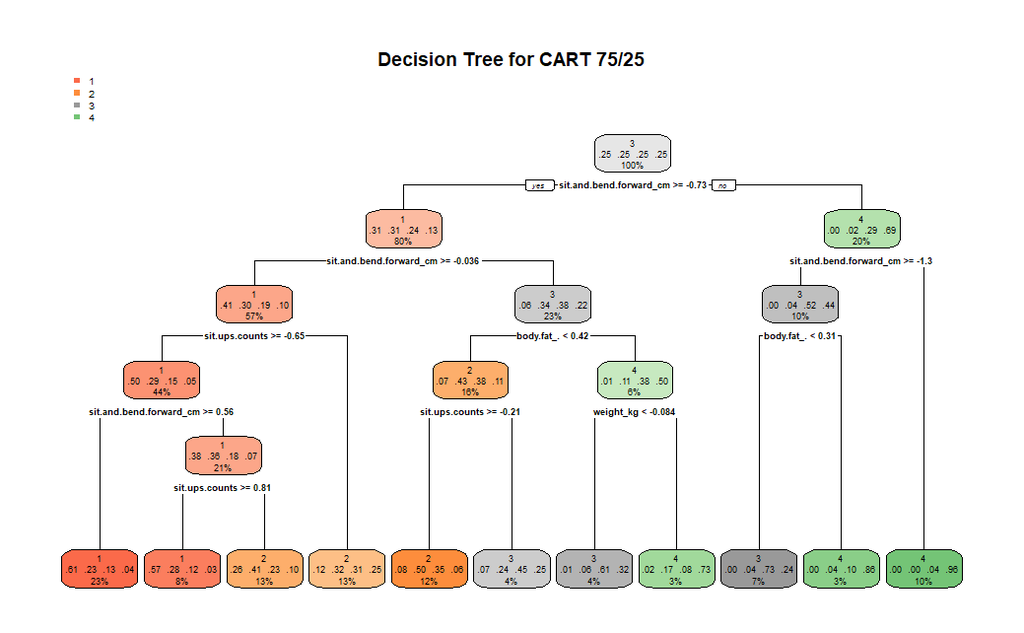

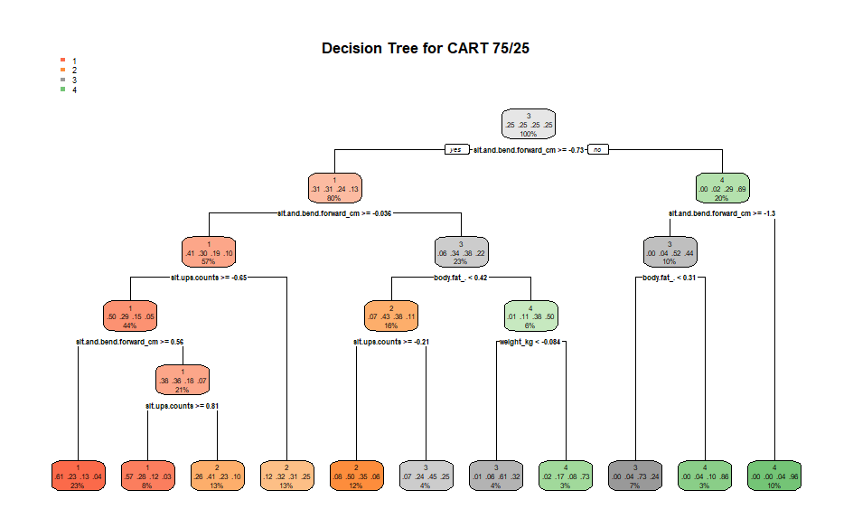

The decision tree representation was utilized, and the findings indicate that the attribute (sit.and.bend.forward_cm) has the greatest Giniindex (impurity reduction) values. As a result, it was placed at the root level, representing the first level of the tree.

###### Prediction on test data and Confusion matrix:

```r
testPred<- predict(model,newdata=test_data)
testPred<- factor(testPred)
test_data$class <- factor(test_data$class)
results<- confusionMatrix(testPred,test_data$class)
conf_matrix <- results$table

print(results)
```

```
Confusion Matrix and Statistics

          Reference
Prediction   1   2   3   4
         1 667 255 116  41
         2 178 478 380 153
         3   8  48 286 126
         4   3  33  30 430

Overall Statistics

               Accuracy : 0.5758
                 95% CI : (0.5585, 0.5929)
    No Information Rate : 0.2649
    P-Value [Acc > NIR] : < 2.2e-16

                  Kappa : 0.4321

 Mcnemar's Test P-Value : < 2.2e-16

Statistics by Class:

                     Class: 1 Class: 2 Class: 3 Class: 4
Sensitivity            0.7792   0.5872  0.35222   0.5733
Specificity            0.8266   0.7060  0.92479   0.9734
Pos Pred Value         0.6182   0.4020  0.61111   0.8669
Neg Pred Value         0.9122   0.8355  0.80970   0.8830
Prevalence             0.2649   0.2519  0.25124   0.2321
Detection Rate         0.2064   0.1479  0.08849   0.1330
Detection Prevalence   0.3338   0.3679  0.14480   0.1535
Balanced Accuracy      0.8029   0.6466  0.63851   0.7734
```

```r
error_rate <- 1 - sum(diag(conf_matrix)) / sum(conf_matrix)
precision <- diag(conf_matrix) / rowSums(conf_matrix)
specificity <- conf_matrix[1, 1] / sum(conf_matrix[1, ])
sensitivity <- conf_matrix[2, 2] / sum(conf_matrix[2, ])

print(paste("specificity:", specificity))
```

```
[1] "specificity: 0.618164967562558"
```

```r
print(paste("sensitivity", sensitivity))
```

```
[1] "sensitivity 0.40201850294365"
```

```r
print(paste("Error Rate:", error_rate))
```

```
[1] "Error Rate: 0.424195544554455"
```

```r
print(paste("Precision for Class 1:", precision[1]))
```

```
[1] "Precision for Class 1: 0.618164967562558"
```

#### Schedule for classification Evaluation:

| Evaluation method | value |
| --- | --- |
| Accuracy | 57.58 |
| Error Rate | 42.41 |
| Sensitivity(Recall) | 40.20 |
| Specificity | 61.81 |
| Precision | 61.81 |

#### Partitioning 80/20

```r
set.seed(1234)
ind=sample (2, nrow(dataset), replace=TRUE, prob=c(0.80 , 0.20))
train_data=dataset[ind==1,]
test_data=dataset[ind==2,]
dim(train_data)
```

```
[1] 10438    12
```

```r
dim(test_data)
```

```
[1] 2613   12
```

```r
# Check class distribution in training set
table(train_data$class)
```

```
   1    2    3    4
2610 2630 2633 2565
```

```r
prop.table(table(train_data$class))
```

```
        1         2         3         4
0.2500479 0.2519640 0.2522514 0.2457367
```

```r
# Check class distribution in testing set
table(test_data$class)
```

```
  1   2   3   4
692 663 659 599
```

```r
prop.table(table(test_data$class))
```

```
        1         2         3         4
0.2648297 0.2537313 0.2522005 0.2292384
```

##### Information Gain (ID3):

```r
features <-dataset[, c("gender","age" ,"height_cm",  "weight_kg" , "body.fat_.", "diastolic", "systolic","gripForce", "sit.and.bend.forward_cm","sit.ups.counts","broad.jump_cm")]
target <- as.factor(dataset$class)
dataset$class = as.factor(dataset$class)

model <- train(x = train_data[, c("gender","age" ,"height_cm",  "weight_kg" , "body.fat_.", "diastolic", "systolic","gripForce", "sit.and.bend.forward_cm","sit.ups.counts","broad.jump_cm")],
  y = train_data$class,method = "rpart",parms = list(split = "information"),tuneGrid = data.frame(cp = seq(0.01, 0.1, by = 0.01)),trControl = trainControl(method = "cv", number = 3))
```

###### Tree based on information gain:

```r
# Load the necessary libraries
library(rpart)
library(rpart.plot)

# Assuming 'model' is your trained model
rpart_model <- model$finalModel

# Print the decision tree
rpart.plot(rpart_model, box.palette = "auto", nn = TRUE, main = "Decision Tree for CART 80/20")
```

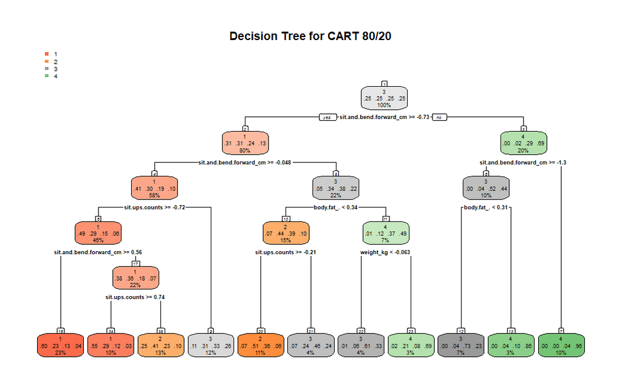

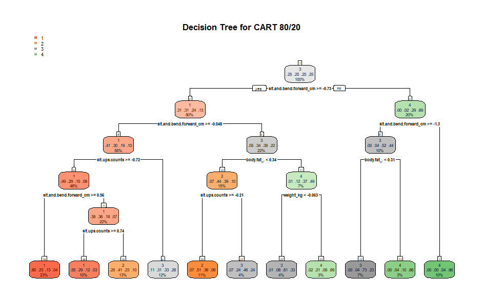

The decision tree representation was utilized, and the findings indicate that the attribute (sit.and.bend.forward_cm) has the greatest information gain. As a result, it was placed at the root level, representing the first level of the tree.

###### Prediction on test data and Confusion matrix:

```r
testPred<- predict(model,newdata=test_data)
testPred<- factor(testPred)
test_data$class <- factor(test_data$class)
results<- confusionMatrix(testPred,test_data$class)
conf_matrix <- results$table

print(results)
```

```
Confusion Matrix and Statistics

          Reference
Prediction   1   2   3   4
         1 558 220  97  37
         2  86 281 221  57
         3  45 127 316 158
         4   3  35  25 347

Overall Statistics

               Accuracy : 0.5748
                 95% CI : (0.5556, 0.5939)
    No Information Rate : 0.2648
    P-Value [Acc > NIR] : < 2.2e-16

                  Kappa : 0.4305

 Mcnemar's Test P-Value : < 2.2e-16

Statistics by Class:

                     Class: 1 Class: 2 Class: 3 Class: 4
Sensitivity            0.8064   0.4238   0.4795   0.5793
Specificity            0.8157   0.8133   0.8311   0.9687
Pos Pred Value         0.6118   0.4357   0.4892   0.8463
Neg Pred Value         0.9212   0.8059   0.8256   0.8856
Prevalence             0.2648   0.2537   0.2522   0.2292
Detection Rate         0.2135   0.1075   0.1209   0.1328
Detection Prevalence   0.3490   0.2468   0.2472   0.1569
Balanced Accuracy      0.8110   0.6186   0.6553   0.7740
```

```r
error_rate <- 1 - sum(diag(conf_matrix)) / sum(conf_matrix)
precision <- diag(conf_matrix) / rowSums(conf_matrix)
specificity <- conf_matrix[1, 1] / sum(conf_matrix[1, ])
sensitivity <- conf_matrix[2, 2] / sum(conf_matrix[2, ])

print(paste("specificity:", specificity))
```

```
[1] "specificity: 0.611842105263158"
```

```r
print(paste("sensitivity", sensitivity))
```

```
[1] "sensitivity 0.435658914728682"
```

```r
print(paste("Error Rate:", error_rate))
```

```
[1] "Error Rate: 0.425181783390739"
```

```r
print(paste("Precision for Class 1:", precision[1]))
```

```
[1] "Precision for Class 1: 0.611842105263158"
```

The above matrix is based on applying our model on test data. #### Schedule for classification Evaluation:

| Evaluation method | value |
| --- | --- |
| Accuracy | 57.48% |
| Error Rate | 42,51% |
| Sensitivity(Recall) | 43.56% |
| Specificity | 61.18% |
| Precision | 61.18% |

##### Gain ratio:

```r
model <- train(x = train_data[, c("gender","age" ,"height_cm",  "weight_kg" , "body.fat_.", "diastolic", "systolic","gripForce", "sit.and.bend.forward_cm","sit.ups.counts","broad.jump_cm")],
  y = train_data$class,method = "rpart",parms = list(split = "gain_ratio"),tuneGrid = data.frame(cp = seq(0.01, 0.1, by = 0.01)),trControl = trainControl(method = "cv", number = 3))
```

###### Tree based on Gain ratio:

```r
# Load the necessary libraries
library(rpart.plot)

# Assuming 'model' is your trained model
rpart_model <- model$finalModel

# Print the decision tree
rpart.plot(rpart_model,main="c4.5 80/20", box.palette = "auto", nn = TRUE)
```

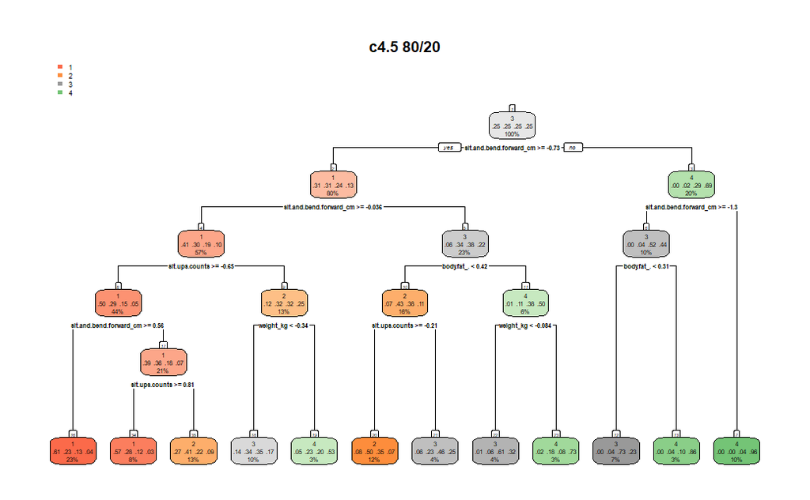

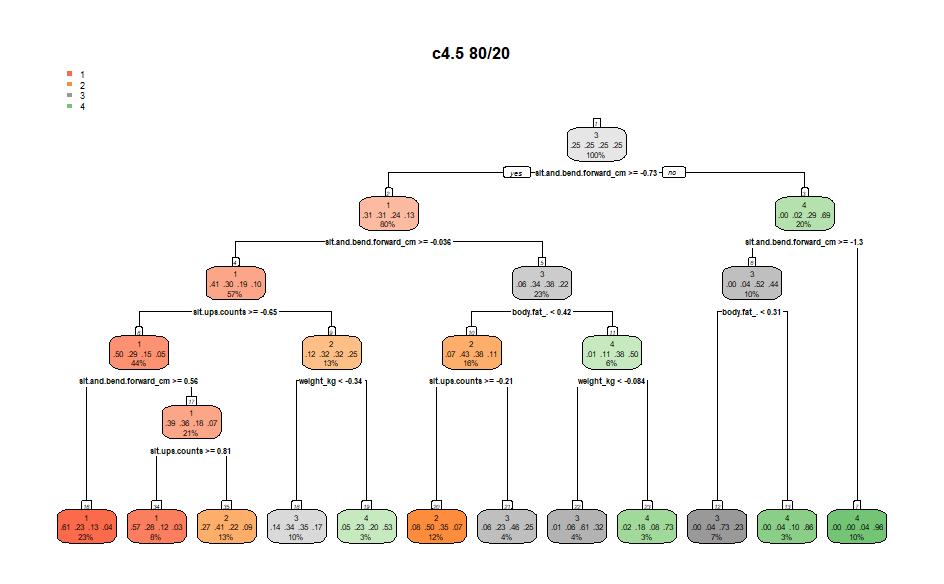

The decision tree representation was utilized, and the findings indicate that the attribute (sit.and.bend.forward_cm) has the greatest gain ratio. As a result, it was placed at the root level, representing the first level of the tree.

###### Prediction on test data and Confusion matrix:

```r
testPred<- predict(model,newdata=test_data)
testPred<- factor(testPred)
test_data$class <- factor(test_data$class)
results<- confusionMatrix(testPred,test_data$class)
conf_matrix <- results$table

print(results)
```

```
Confusion Matrix and Statistics

          Reference
Prediction   1   2   3   4
         1 539 205  92  34
         2  97 289 222  59
         3  49 118 305 140
         4   7  51  40 366

Overall Statistics

               Accuracy : 0.5737
                 95% CI : (0.5544, 0.5927)
    No Information Rate : 0.2648
    P-Value [Acc > NIR] : < 2.2e-16

                  Kappa : 0.4295

 Mcnemar's Test P-Value : < 2.2e-16

Statistics by Class:

                     Class: 1 Class: 2 Class: 3 Class: 4
Sensitivity            0.7789   0.4359   0.4628   0.6110
Specificity            0.8277   0.8062   0.8429   0.9513
Pos Pred Value         0.6195   0.4333   0.4984   0.7888
Neg Pred Value         0.9122   0.8078   0.8231   0.8916
Prevalence             0.2648   0.2537   0.2522   0.2292
Detection Rate         0.2063   0.1106   0.1167   0.1401
Detection Prevalence   0.3330   0.2553   0.2342   0.1776
Balanced Accuracy      0.8033   0.6210   0.6529   0.7812
```

```r
error_rate <- 1 - sum(diag(conf_matrix)) / sum(conf_matrix)
precision <- diag(conf_matrix) / rowSums(conf_matrix)
specificity <- conf_matrix[1, 1] / sum(conf_matrix[1, ])
sensitivity <- conf_matrix[2, 2] / sum(conf_matrix[2, ])

print(paste("specificity:", specificity))
```

```
[1] "specificity: 0.619540229885058"
```

```r
print(paste("sensitivity", sensitivity))
```

```
[1] "sensitivity 0.43328335832084"
```

```r
print(paste("Error Rate:", error_rate))
```

```
[1] "Error Rate: 0.426329889016456"
```

```r
print(paste("Precision for Class 1:", precision[1]))
```

```
[1] "Precision for Class 1: 0.619540229885058"
```

####Schedule for classification Evaluation:

| Evaluation method | value |
| --- | --- |
| Accuracy | 57.37% |
| Error Rate | 42.63% |
| Sensitivity(Recall) | 43.32% |
| Specificity | 61.95% |
| Precision | 61.95% |

##### Gini index:

```r
# Example of hyperparameter tuning
model <- train(x = train_data[, c("gender","age" ,"height_cm",  "weight_kg" , "body.fat_.", "diastolic", "systolic","gripForce", "sit.and.bend.forward_cm","sit.ups.counts","broad.jump_cm")],
  y = train_data$class,method = "rpart",parms = list(split = "gini"),tuneGrid = data.frame(cp = seq(0.01, 0.1, by = 0.01)),trControl = trainControl(method = "cv", number = 3))
```

###### Tree based on Gini index :

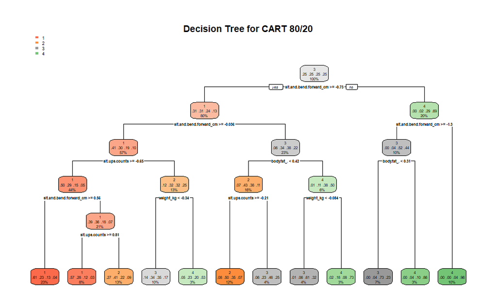

```r
# Load the necessary libraries
library(rpart.plot)

# Assuming 'model' is your trained model
rpart_model <- model$finalModel

# Print the decision tree
rpart.plot(rpart_model, main = "Decision Tree for CART 80/20")
```

The decision tree representation was utilized, and the findings indicate that the attribute (sit.and.bend.forward_cm) has the greatest Giniindex (impurity reduction) values. As a result, it was placed at the root level, representing the first level of the tree.

###### Prediction on test data and Confusion matrix:

```r
testPred<- predict(model,newdata=test_data)
testPred<- factor(testPred)
test_data$class <- factor(test_data$class)
results<- confusionMatrix(testPred,test_data$class)
conf_matrix <- results$table

print(results)
```

```
Confusion Matrix and Statistics

          Reference
Prediction   1   2   3   4
         1 539 205  92  34
         2  97 289 222  59
         3  49 118 305 140
         4   7  51  40 366

Overall Statistics

               Accuracy : 0.5737
                 95% CI : (0.5544, 0.5927)
    No Information Rate : 0.2648
    P-Value [Acc > NIR] : < 2.2e-16

                  Kappa : 0.4295

 Mcnemar's Test P-Value : < 2.2e-16

Statistics by Class:

                     Class: 1 Class: 2 Class: 3 Class: 4
Sensitivity            0.7789   0.4359   0.4628   0.6110
Specificity            0.8277   0.8062   0.8429   0.9513
Pos Pred Value         0.6195   0.4333   0.4984   0.7888
Neg Pred Value         0.9122   0.8078   0.8231   0.8916
Prevalence             0.2648   0.2537   0.2522   0.2292
Detection Rate         0.2063   0.1106   0.1167   0.1401
Detection Prevalence   0.3330   0.2553   0.2342   0.1776
Balanced Accuracy      0.8033   0.6210   0.6529   0.7812
```

```r
error_rate <- 1 - sum(diag(conf_matrix)) / sum(conf_matrix)
precision <- diag(conf_matrix) / rowSums(conf_matrix)
specificity <- conf_matrix[1, 1] / sum(conf_matrix[1, ])
sensitivity <- conf_matrix[2, 2] / sum(conf_matrix[2, ])

print(paste("specificity:", specificity))
```

```
[1] "specificity: 0.619540229885058"
```

```r
print(paste("sensitivity", sensitivity))
```

```
[1] "sensitivity 0.43328335832084"
```

```r
print(paste("Error Rate:", error_rate))
```

```
[1] "Error Rate: 0.426329889016456"
```

```r
print(paste("Precision for Class 1:", precision[1]))
```

```
[1] "Precision for Class 1: 0.619540229885058"
```

#### Schedule for classification Evaluation:

| Evaluation method | value |
| --- | --- |
| Accuracy | 57.37% |
| Error Rate | 42.63% |
| Sensitivity(Recall) | 43.32% |
| Specificity | 61.95% |
| Precision | 61.95% |

#### Classification Analysis:

ID3:

Accuracy for 70/30 partitioning: 0.576 Accuracy for 75/25 partitioning: 0.578 Accuracy for 80/20 partitioning: 0.5748 C4.5:

Accuracy for 70/30 partitioning: 0.5786 Accuracy for 75/25 partitioning: 0.5758 Accuracy for 80/20 partitioning: 0.573 CART:

Accuracy for 70/30 partitioning: 0.5786 Accuracy for 75/25 partitioning: 0.5758 Accuracy for 80/20 partitioning: 0.5737 Analysis:

Overall, the accuracy values for the three decision tree algorithms (ID3, C4.5, and CART) are relatively close across different partition sizes.

The highest accuracy is observed for C4.5 at 70/30 partitioning (0.5786), followed closely by CART and ID3 at the same partition size.

ID3 performs consistently across different partition sizes, maintaining accuracy around 0.576 to 0.578.

C4.5 and CART show slight variations in accuracy across partition sizes but generally stay close to each other.

The impact of changing partition sizes on accuracy seems minimal, with fluctuations within a narrow range.

### 5.2 Clustering:

Data clustering is the act of dividing data into distinct groups or clusters. It is an unsupervised learning technique, meaning it doesn’t rely on known class labels “Class” in the training data. The data within each cluster share similarities with one another and differ from data in other clusters. In this case, we will employ the k-means clustering algorithm.

### 1- Data prepreocessing before Clustering:

In order to optimize the performance of our models and achieve the most accurate results, it is crucial to preprocess certain attributes before applying data clustering techniques. where we will remove the class label and adding the old Age attribute “before discretizing”, also we will convert all attribute into numeric:

#### 1.1: Remove Class lable:

For unsupervised learning, At first we need to removing class label “Class”.

```r
#in case we need the old dataset (with class label)
dataWithclass <-dataset

#delete class label
dataset <- dataset [,-which(names(dataset)== "class")]

#varify removing class
str(dataset)
```

```
'data.frame':   13051 obs. of  11 variables:
 $ age                    : Factor w/ 3 levels "[21,35)","[35,49)",..: 1 1 1 1 1 2 2 1 3 1 ...
 $ gender                 : Factor w/ 2 levels "0","1": 2 2 2 2 2 1 1 2 2 2 ...
 $ height_cm              : num  0.425 -0.451 1.301 0.689 0.605 ...
 $ weight_kg              : num  0.6441 -0.9842 0.8753 0.2973 0.0125 ...
 $ body.fat_.             : num  -0.246 -1.033 -0.415 -0.653 -0.836 ...
 $ diastolic              : num  0.112 -0.168 1.232 -0.261 -0.821 ...
 $ systolic               : num  -0.0104 -0.2839 1.494 1.1521 -0.2155 ...
 $ gripForce              : num  1.6783 -0.0753 0.7209 0.3986 0.5977 ...
 $ sit.and.bend.forward_cm: num  0.38131 0.12708 -0.39348 -0.00609 1.43453 ...
 $ sit.ups.counts         : num  1.43 0.92 0.628 0.92 0.336 ...
 $ broad.jump_cm          : num  0.658 0.97 -0.278 0.71 0.658 ...
```

As Showing in data frame above, deletion the “calss” attribute was successful.

#### 1.2 Add AgeBeforeDis:

Based on our previous findings about discretizing the age attribute, we discovered that using fixed intervals may not accurately represent the true distribution of the data. This can result in biased or inaccurate cluster assignments.

To overcome this issue, we suggest removing the discretized age attribute and adding the original age attribute called “AgeBeforeDis”. This change is expected to improve the performance of our model, make the analysis easier, and enable more straightforward comparisons between different group.

```r
dataset$age <- AgeBeforeDis

#verify updating
str(dataset)
```

```
'data.frame':   13051 obs. of  11 variables:
 $ age                    : num  27 25 31 32 28 36 42 33 54 28 ...
 $ gender                 : Factor w/ 2 levels "0","1": 2 2 2 2 2 1 1 2 2 2 ...
 $ height_cm              : num  0.425 -0.451 1.301 0.689 0.605 ...
 $ weight_kg              : num  0.6441 -0.9842 0.8753 0.2973 0.0125 ...
 $ body.fat_.             : num  -0.246 -1.033 -0.415 -0.653 -0.836 ...
 $ diastolic              : num  0.112 -0.168 1.232 -0.261 -0.821 ...
 $ systolic               : num  -0.0104 -0.2839 1.494 1.1521 -0.2155 ...
 $ gripForce              : num  1.6783 -0.0753 0.7209 0.3986 0.5977 ...
 $ sit.and.bend.forward_cm: num  0.38131 0.12708 -0.39348 -0.00609 1.43453 ...
 $ sit.ups.counts         : num  1.43 0.92 0.628 0.92 0.336 ...
 $ broad.jump_cm          : num  0.658 0.97 -0.278 0.71 0.658 ...
```

As Showing that age attribute becomes on continuous value, which means updating age was successful.

#### 1.3 check datatype:

for Clustering task all data types should be numeric, and from the data frame from last chunk,there is only one attribute that should be convert, which is gender attribute. where Encoding gender attribute makes data type to Factor, so we should convert it to numeric before clustering.

#### Convert gender attribute type to numeric:

```r
dataset$gender <- as.numeric(as.character(dataset$gender))

# Verify the conversion
sapply(dataset, class)
```

```
                    age                  gender               height_cm
              "numeric"               "numeric"               "numeric"
              weight_kg              body.fat_.               diastolic
              "numeric"               "numeric"               "numeric"
               systolic               gripForce sit.and.bend.forward_cm
              "numeric"               "numeric"               "numeric"
         sit.ups.counts           broad.jump_cm
              "numeric"               "numeric"
```

```r
#scale all attributes in the dataset so they would be standardized
#dataset <- scale(dataset)
```

Now all attribute are numeric, so we are ready to perform k-means clustering.

#### determine and visualize optimal number of clusters:

In order to determine the optimal number of clusters (k) for our dataset, we will experiment with three different sizes of k for clustering. To assist with this determination, we will employ various methods( kmeansruns, calculate the average silhouette ,total within-cluster sum of square and the BCubed(precision and recall) ) that aid in identifying the most suitable k value for our specific dataset.

```r
#install necessary packages:

library(factoextra)
library(fpc)
library(cluster)
library(NbClust)
```

#### a) kmeansruns method:

This function assigns data points to clusters based on proximity to centroids. To determine the optimal number of clusters,different techniques like the elbow method or silhouette analysis can be used. This helps identify the value of k that produces the best clustering performance.

```r
library(fpc)
kmeansruns.result <- kmeansruns(dataset)
kmeansruns.result
```

[output not shown]

[output cut: 294 more lines]

[output not shown]

[figure not shown]

[figure not shown]

[figure not shown]

[figure not shown]

[figure not shown]